# Cluster Trends

Janette Avelar

2024-03-07

```r
# start by creating cluster subsets
#subset values
deeper <- cluster %>%
  filter(proposed_cluster_for_preliminary_24_analysis == "Deeper learning") %>%
  select(label = tag) %>%
  left_join(labels, by = "label") %>%
  pull(var)
ed_justice <- cluster %>%
  filter(proposed_cluster_for_preliminary_24_analysis == "Ed justice") %>%
  select(label = tag) %>%
  left_join(labels, by = "label") %>%
  pull(var)
individualized <- cluster %>%
  filter(proposed_cluster_for_preliminary_24_analysis == "Individualized") %>%
  select(label = tag) %>%
  left_join(labels, by = "label") %>%
  pull(var)
postsecondary <- cluster %>%
  filter(proposed_cluster_for_preliminary_24_analysis == "Postsecondary") %>%
  select(label = tag) %>%
  left_join(labels, by = "label") %>%
  pull(var)
# none <- cluster %>%
#   filter(proposed_cluster_for_preliminary_24_analysis == "None" |
#            proposed_cluster_for_preliminary_24_analysis == "None?") %>%
#   select(label = tag) %>%
#   left_join(labels, by = "label") %>%
#   pull(var)
```

# Deeper Learning Cluster

Tags:  
-assessments for deeper learning  
-competency/mastery-based education  
-competency framework  
-design thinking process  
-interdisciplinary  
-makerspace  
-multiple opportunities to demonstrate mastery  
-project-based learning  
-performance based assessment  
-place-based learning  
-student-led conferences  
-students develop projects

Guiding question: How have the rates of deeper learning tags changed each year since 2019?

```r
#set up repeating schools
repeaters <- dat %>%
  select(school_id, year) %>%
  unique() %>%
  mutate(rate = 1) %>%
  pivot_wider(names_from = "year",
              values_from = "rate") %>%
  rowwise() %>%
  mutate(participate = sum(`2019`, `2021`, `2022`, `2023`, na.rm = TRUE)) %>%
  filter(participate > 1) %>%
  pull(school_id)
#set up totals
tots <- dat %>%
  group_by(year) %>%
  summarize(total = n_distinct(school_id)) %>%
  unique()
#labels
# labs <- labels %>%
#   filter(year == 2023) %>%
#   select(label, x = year, y = pct)
#prep data function across schools
prep_across <- function(data, cluster){
  dat <- data %>%
    filter(var %in% cluster) %>%
    group_by(var, year) %>%
    summarize(n = sum(usage)) %>%
    ungroup() %>%
    left_join(tots, by = "year") %>%
    mutate(pct = n/total) %>%
    left_join(labels, by = "var") %>%
    group_by(var) %>%
    mutate(x_coord = max(year),
           y_coord = pct[which.max(year)])

  return(dat)
}
#prep data function within schools
prep_within <- function(data, cluster){
  dat <- data %>%
    filter(var %in% cluster) %>%
    filter(school_id %in% repeaters) %>%
    arrange(school_id, year) %>%
    group_by(school_id) %>%
    mutate(wave = dense_rank(year)) %>%
    ungroup() %>%
    arrange(school_id, year) %>%
    group_by(school_id, var) %>%
    mutate(change = usage - lag(usage)) %>%
    ungroup() %>%
    mutate(adds = ifelse(change == 1, 1, NA),
           drops = ifelse(change == -1, 1, NA)) %>%
    group_by(var, year) %>%
    summarize(`Overall rate` = sum(usage, na.rm = TRUE),
              `Average change` = sum(change, na.rm = TRUE),
              Adds = sum(adds, na.rm = TRUE),
              Drops = sum(drops, na.rm = TRUE)) %>%
    ungroup() %>%
    pivot_longer(cols = c(`Overall rate`, `Average change`, Adds, Drops),
                 names_to = "type",
                 values_to = "n") %>%
    left_join(labels, by = "var") %>%
    mutate(type = factor(type, levels = c("Overall rate", "Average change", "Adds", "Drops")))
           # x_coord = max(year),
           # y_coord = n[which.max(year)])

  return(dat)
}
#plot function for across schools
cluster_plot_across <- function(data, x, y, labels) {
  #palette <- c("#BC2582", "#FFA630", "#FFDE42", "#99C24D", "#218380", "#D3B7D7")

  labels <- data %>%
    select(label, x_coord, y_coord) %>%
    unique()

  plot <- ggplot(data, aes_string(x = x, y = y, color = "label")) +
    geom_point() +
    geom_line() +
    theme_bw() +
    scale_x_continuous(limits = c(2019, 2025),
                       expand = c(0.01, 0),
                       breaks = unique(data$year)) + #expand 0.025, .3
    scale_y_continuous(limits = c(0, 1),
                       expand = c(0, 0),
                       labels = scales::percent_format(accuracy = 1)) +
    theme(legend.position = "none") +
    geom_text(data = labels,
              aes_string(label = str_wrap("label", 10), x = "x_coord", y = "y_coord"),
              position = position_jitterdodge(dodge.width = 0.5, jitter.height = 0.025),
              hjust = -.05,
              vjust = 0.5)

  return(plot)
}
#plot function for within schools
cluster_plot_within <- function(data, x, y, labels){
  # labels <- data %>%
  #   select(label, x_coord, y_coord) %>%
  #   unique()

  plot <- ggplot(data, aes_string(x = x, y = y, color = "label")) +
    geom_point() +
    geom_line() +
    theme_bw() +
    # #scale_color_manual(values = palette) +
    scale_x_continuous(expand = expansion(mult = c(.025, .3))) +
    theme(panel.grid.major.x = element_blank(),
          panel.grid.minor.x = element_blank()) +
    theme(legend.position = "none") +
    facet_wrap(~type) +
    labs(x = "Year",
       y = "Tag selection (N)")

  return(plot)
}
```

### Across schools

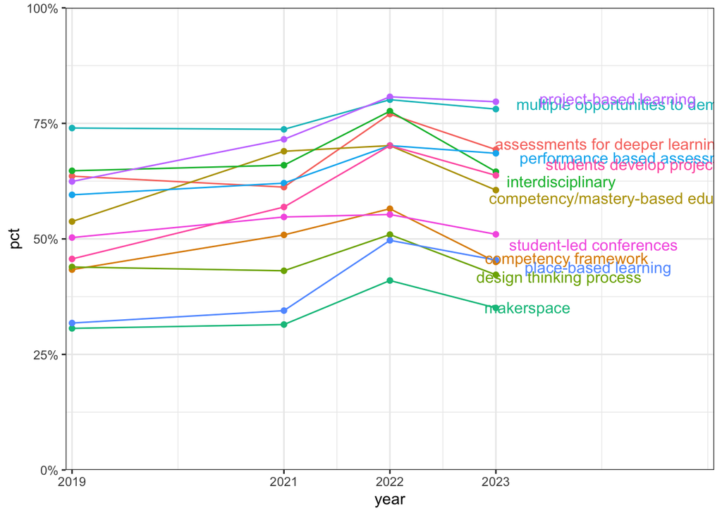

```r
deep <- prep_across(dat, deeper)
cluster_plot_across(deep, "year", "pct", labels)
```

### Within schools

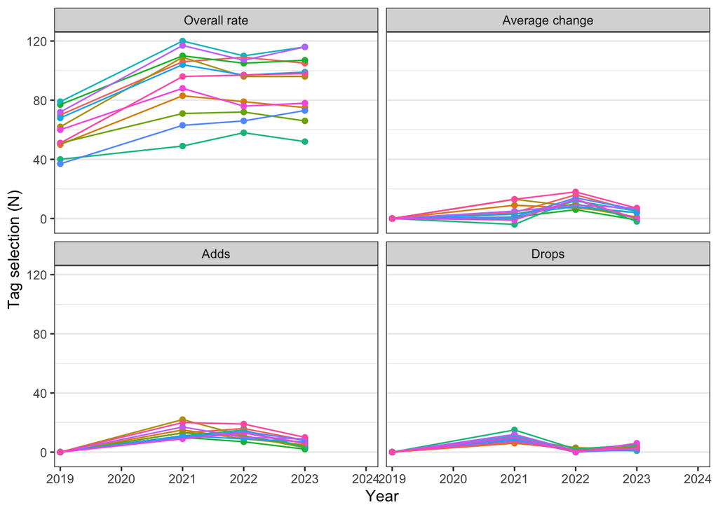

```r
deep <- prep_within(dat, deeper)
cluster_plot_within(deep, deep$year, deep$n, labels)
```

## Educational Justice Cluster

Tags:  
-adult wellness/SEL  
-anti-racist practices  
-assessments for social-emotional skills  
-teachers as co-leaders  
-co-leadership  
-family and community support services  
-culturally responsive practices  
-design to meet needs of students who have been marginalized  
-hiring for equity and inclusion values  
-all courses designed for inclusion  
-mental health services  
-physical well being services  
-reallocation of resources for those most in need  
-restorative practices  
-SEL curriculum  
-SEL integration school-wide  
-social justice focus  
-translanguaging  
-trauma-informed practices

### Across schools

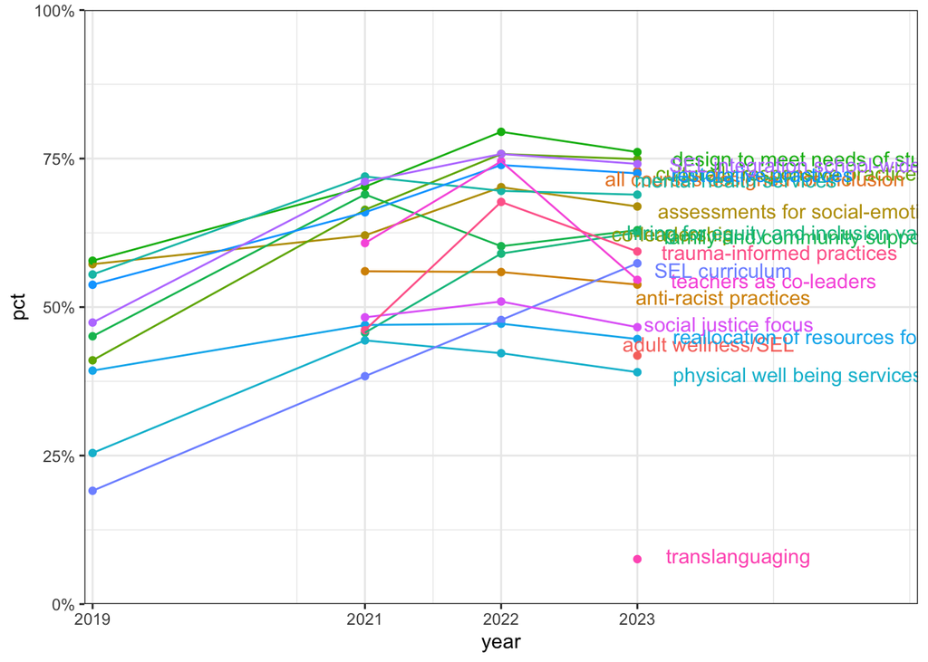

```r
justice_dat <- prep_across(dat, ed_justice)
cluster_plot_across(justice_dat, "year", "pct", labels)
```

### Within schools

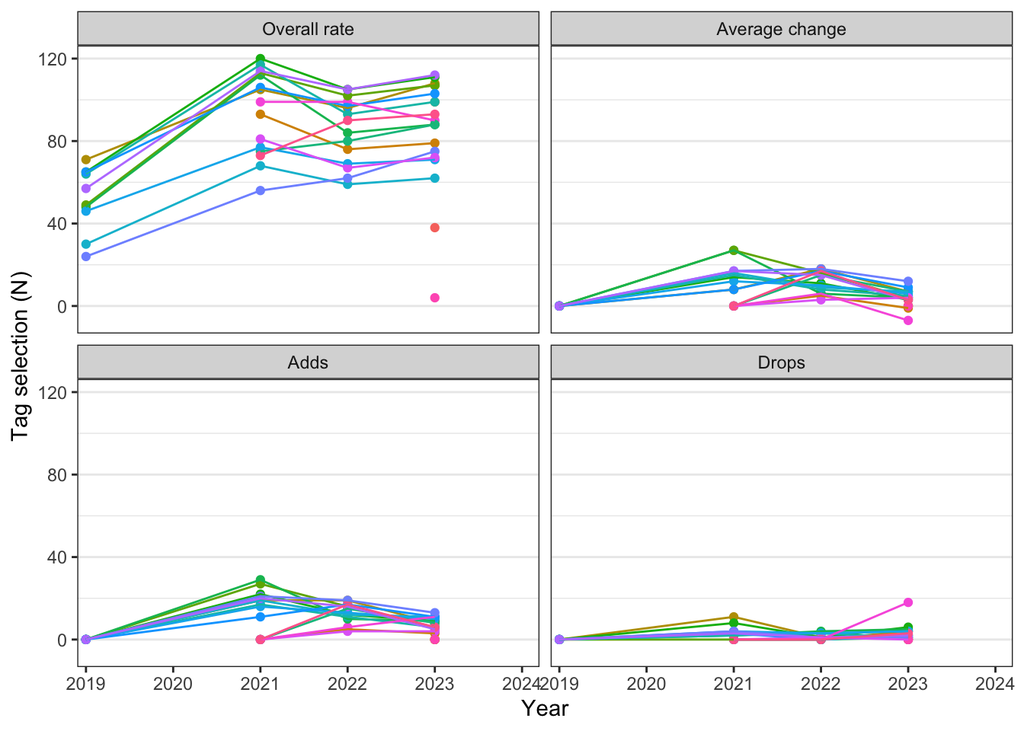

```r
justice_dat <- prep_within(dat, ed_justice)
cluster_plot_within(justice_dat, justice_dat$year, justice_dat$n, labels)
```

## Individualized Cluster

Tags:  
-accommodations provided to all students  
-blended learning  
-flex model  
-flipped classroom  
-interoperable data from multiple technologies  
-1:1 mentoring  
-station rotation  
-students access their own data  
-self-paced learning

### Across schools

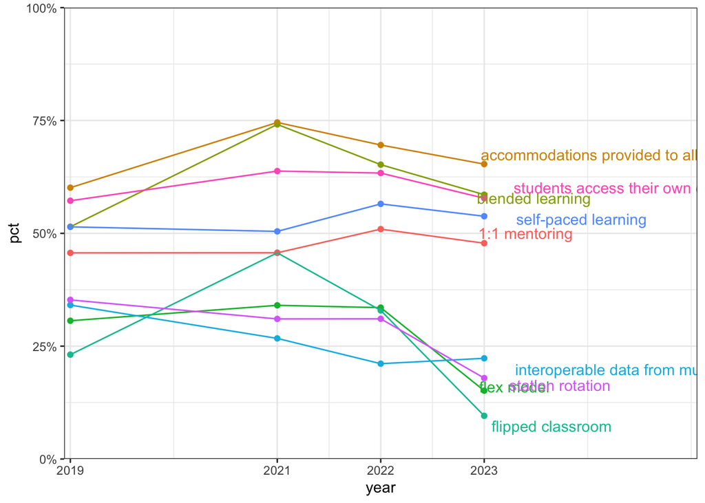

```r
ind_dat <- prep_across(dat, individualized)
cluster_plot_across(ind_dat, "year", "pct", labels)
```

### Within schools

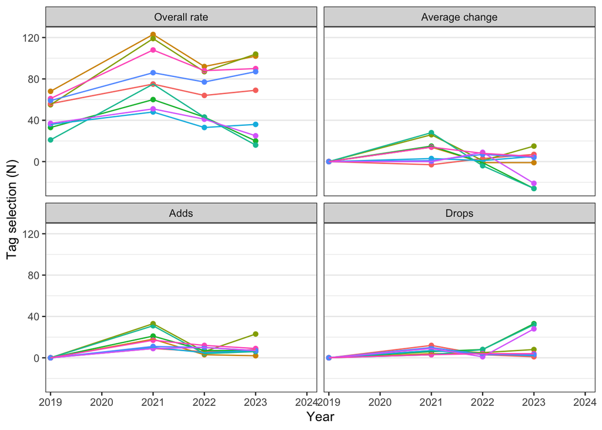

```r
ind_dat <- prep_within(dat, individualized)
cluster_plot_within(ind_dat, ind_dat$year, ind_dat$n, labels)
```

## Postsecondary Cluster

Tags:  
-à la carte model  
-assessments for career readiness  
-career prep and work-based learning  
-community-based organizations as co-leaders  
-industry-based partners as co-leaders  
-community and business partnerships  
-early college high school  
-extended learning opportunities  
-students earn industry credentials

### Across schools

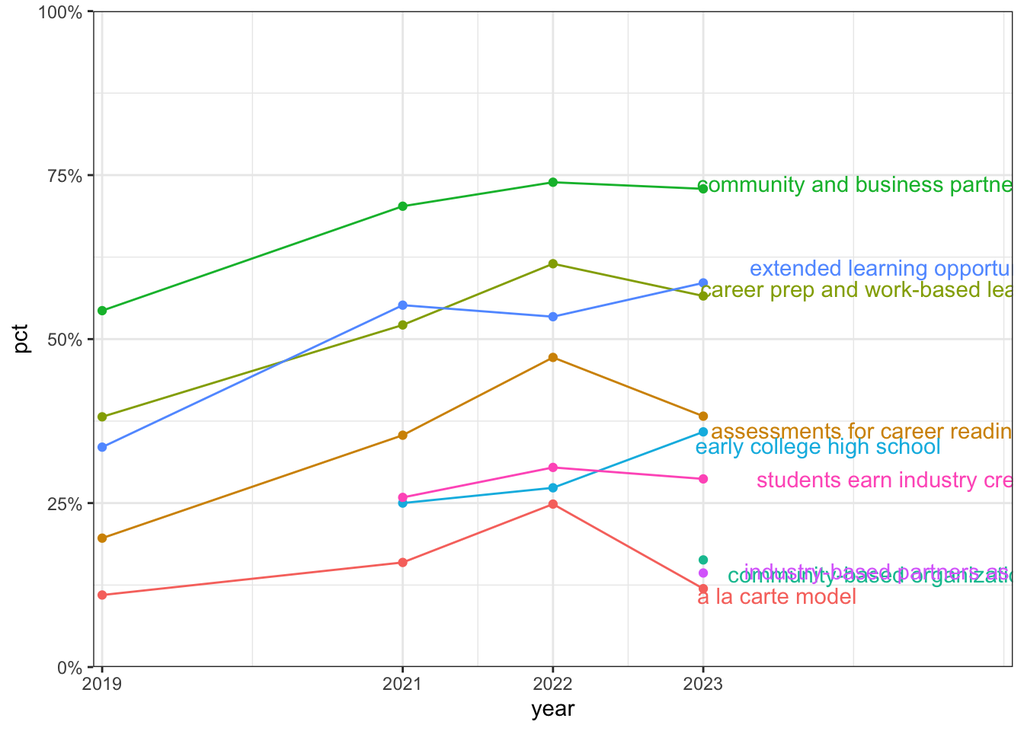

```r
post_dat <- prep_across(dat, postsecondary)
cluster_plot_across(post_dat, "year", "pct", labels)
```

### Within schools

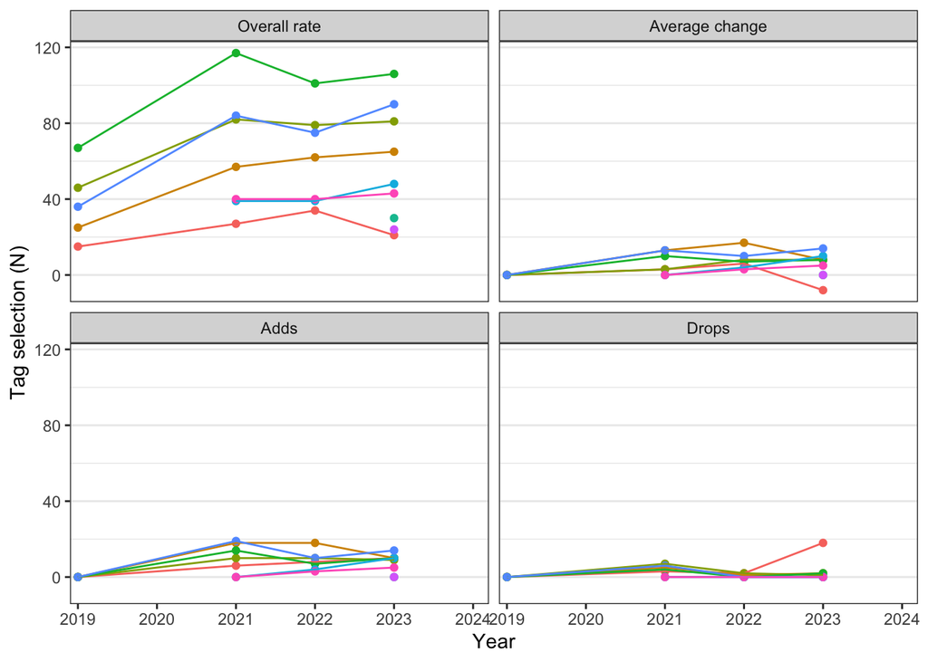

```r
post_dat <- prep_within(dat, postsecondary)
cluster_plot_within(post_dat, post_dat$year, post_dat$n, labels)
```